# TRABAJO_FINAL

Author

Cristina Martinez, Laura López, Veronica Yebra, Marina Parra

# 0. Carga de librerias y datos

```r
library(tidyverse)
library(sf)
library(dplyr)
library(ggplot2)
library(dbscan)
library(concaveman)
library(tmap)
library(rpart)
library(rpart.plot)
library(patchwork)
library(spdep)
```

```r
# importamos la base de datos
datos <- read.csv("Data_Housing_Madrid.csv", stringsAsFactors = TRUE)
head(datos) # viviendas de madrid con sus características
```

```
      X house.price   RP crime built.area  age  retired children immigrants
1 11548        3571 0.26  0.41         70 40.0 20.78242 12.64032  13.430590
2  7700        3115 0.14  0.28         61 40.0 16.94858 14.20422   7.080645
3  6271        2940 0.15  0.27         92 40.0 22.22094 13.08628   7.956299
4  1620        2811 0.20  0.35         65 40.0 12.39859 16.42624   6.552713
5  3500        3808 0.17  0.30        130 15.0 20.78242 12.64032  13.430590
6  1972        4407 0.22  0.53         75  7.5 21.81914 11.66186  13.947801
  shopping historical baths type.house        floor  good.cond garage elevator
1        0          0     2       piso      primera      bueno     no       no
2        0          0     1       piso   seg.-terc.      bueno     no       no
3        0          0     2       piso   seg.-terc. a_reformar     no       si
4        0          0     1       piso cuar.-quinta      bueno    ZZZ       no
5        0          0     2       piso   seg.-terc.      bueno     no       si
6        0          0     1      atico   seg.-terc. a_reformar    ZZZ       no
  air.cond swimming.pool M.30 longitude latitude
1      ZZZ           ZZZ    0 -3.656538 40.43130
2       si            no    0 -3.721426 40.48234
3       no            no    0 -3.647869 40.40897
4       si           ZZZ    0 -3.754118 40.37485
5      ZZZ            si    0 -3.670743 40.48133
6       si            no    0 -3.731661 40.40480
```

# 1. Depuracion inicial de la base de datos

## 0. Exploracion incial

```r
summary(datos)
```

```
       X          house.price          RP           crime
 Min.   :    1   Min.   :  900   Min.   :0.06   Min.   :0.0600
 1st Qu.: 2971   1st Qu.: 2828   1st Qu.:0.21   1st Qu.:0.2900
 Median : 5924   Median : 3545   Median :0.26   Median :0.4300
 Mean   : 5928   Mean   : 3728   Mean   :0.28   Mean   :0.4369
 3rd Qu.: 8896   3rd Qu.: 4400   3rd Qu.:0.33   3rd Qu.:0.5500
 Max.   :11796   Max.   :20131   Max.   :0.72   Max.   :0.7700
   built.area           age            retired         children
 Min.   :  15.00   Min.   :  0.00   Min.   :11.58   Min.   : 8.897
 1st Qu.:  62.00   1st Qu.: 15.00   1st Qu.:16.56   1st Qu.:11.181
 Median :  80.00   Median : 28.91   Median :18.68   Median :12.776
 Mean   :  98.79   Mean   : 23.93   Mean   :18.51   Mean   :12.905
 3rd Qu.: 110.00   3rd Qu.: 30.00   3rd Qu.:20.78   3rd Qu.:14.239
 Max.   :2500.00   Max.   :100.00   Max.   :22.75   Max.   :18.374
   immigrants        shopping        historical         baths
 Min.   : 6.064   Min.   :0.0000   Min.   :0.0000   Min.   :1.000
 1st Qu.: 8.043   1st Qu.:0.0000   1st Qu.:0.0000   1st Qu.:1.000
 Median :12.068   Median :0.0000   Median :0.0000   Median :1.000
 Mean   :12.624   Mean   :0.4085   Mean   :0.3456   Mean   :1.542
 3rd Qu.:17.560   3rd Qu.:1.0000   3rd Qu.:1.0000   3rd Qu.:2.000
 Max.   :20.543   Max.   :1.0000   Max.   :1.0000   Max.   :7.000
   type.house            floor           good.cond    garage     elevator
 atico  : 662   bajo        : 385   a_reformar:1569   no :5672   no :3545
 chalet : 377   cuar.-quinta:1907   bueno     :8883   si :3050   si :6889
 estudio: 244   primera     :1980   ZZZ       :  60   ZZZ:1790   ZZZ:  78
 piso   :9065   seg.-terc.  :3186
 ZZZ    : 164   sexta_o_mas :1103
                ZZZ         :1951
 air.cond   swimming.pool      M.30          longitude         latitude
 no :4539   no :7087      Min.   :0.0000   Min.   :-3.792   Min.   :40.34
 si :4826   si :1853      1st Qu.:0.0000   1st Qu.:-3.708   1st Qu.:40.39
 ZZZ:1147   ZZZ:1572      Median :0.0000   Median :-3.691   Median :40.42
                          Mean   :0.1335   Mean   :-3.685   Mean   :40.42
                          3rd Qu.:0.0000   3rd Qu.:-3.663   3rd Qu.:40.45
                          Max.   :1.0000   Max.   :-3.546   Max.   :40.53
```

## 1. Actualización del precio

La base de datos es del año 2010, por lo que tenemos que actualizar el precio medio de las casas con la variable `house.price`. Para ello, se utilizan datos del Ministerio de Vivienda (Observatorio de Vivienda y Suelo), concretamente el valor tasado de la vivienda (€/m²) para municipios de más de 25.000 habitantes en la Comunidad de Madrid.

Para actualizar los datos, lo hacemos aplicando la tasa de crecimiento a los datos:

$Precio_{Actualizado} = Precio_{Original} \times \left(1 + \frac{\text{Porcentaje de Crecimiento}}{100}\right)$

En este caso, los valores considerados son:

- 2010 (T1): 3296.3 €/m²
- 2025 (T4): 5286.2 €/m²

```r
# tasa de variación desde 2010 hasta 2025
tasa_variacion <- (5286.2-3296.3)/3296.3

# Creamos una nueva columna con el precio total actualizado a 2026
datos$precio_actualizado <- datos$house.price * (1 + tasa_variacion)
```

## 2. Imputar los NA

Con la exploracion de datos, hemos visto que existen valores faltantes en las variables categoricas codificados como *ZZZ*. Vamos a imputar dichos valores de las variables `type.house`, `floor`, `good.cond`, `garage`, `elevator`, `air.cond`, `swimming.pool`.

> Para las variables binarias `garage`, `elevator`, `air.cond` y `swimming.pool`, se asumió que la ausencia de información sobre la disponibilidad de estas características equivale a su no presencia en la vivienda. Por tanto, los valores no observados en estas variables fueron imputados con el valor 0.

```r
datos <- datos |>
  mutate(
    garage = case_when(
      trimws(as.character(garage)) == "si"  ~ 1,
      trimws(as.character(garage)) == "no"  ~ 0,
      trimws(as.character(garage)) == "ZZZ" ~ 0
    ),
    elevator = case_when(
      trimws(as.character(elevator)) == "si"  ~ 1,
      trimws(as.character(elevator)) == "no"  ~ 0,
      trimws(as.character(elevator)) == "ZZZ" ~ 0
    ),
    air.cond = case_when(
      trimws(as.character(air.cond)) == "si"  ~ 1,
      trimws(as.character(air.cond)) == "no"  ~ 0,
      trimws(as.character(air.cond)) == "ZZZ" ~ 0
    ),
    swimming.pool = case_when(
      trimws(as.character(swimming.pool)) == "si"  ~ 1,
      trimws(as.character(swimming.pool)) == "no"  ~ 0,
      trimws(as.character(swimming.pool)) == "ZZZ" ~ 0
    )
  )
summary(datos)
```

```
       X          house.price          RP           crime
 Min.   :    1   Min.   :  900   Min.   :0.06   Min.   :0.0600
 1st Qu.: 2971   1st Qu.: 2828   1st Qu.:0.21   1st Qu.:0.2900
 Median : 5924   Median : 3545   Median :0.26   Median :0.4300
 Mean   : 5928   Mean   : 3728   Mean   :0.28   Mean   :0.4369
 3rd Qu.: 8896   3rd Qu.: 4400   3rd Qu.:0.33   3rd Qu.:0.5500
 Max.   :11796   Max.   :20131   Max.   :0.72   Max.   :0.7700
   built.area           age            retired         children
 Min.   :  15.00   Min.   :  0.00   Min.   :11.58   Min.   : 8.897
 1st Qu.:  62.00   1st Qu.: 15.00   1st Qu.:16.56   1st Qu.:11.181
 Median :  80.00   Median : 28.91   Median :18.68   Median :12.776
 Mean   :  98.79   Mean   : 23.93   Mean   :18.51   Mean   :12.905
 3rd Qu.: 110.00   3rd Qu.: 30.00   3rd Qu.:20.78   3rd Qu.:14.239
 Max.   :2500.00   Max.   :100.00   Max.   :22.75   Max.   :18.374
   immigrants        shopping        historical         baths
 Min.   : 6.064   Min.   :0.0000   Min.   :0.0000   Min.   :1.000
 1st Qu.: 8.043   1st Qu.:0.0000   1st Qu.:0.0000   1st Qu.:1.000
 Median :12.068   Median :0.0000   Median :0.0000   Median :1.000
 Mean   :12.624   Mean   :0.4085   Mean   :0.3456   Mean   :1.542
 3rd Qu.:17.560   3rd Qu.:1.0000   3rd Qu.:1.0000   3rd Qu.:2.000
 Max.   :20.543   Max.   :1.0000   Max.   :1.0000   Max.   :7.000
   type.house            floor           good.cond        garage
 atico  : 662   bajo        : 385   a_reformar:1569   Min.   :0.0000
 chalet : 377   cuar.-quinta:1907   bueno     :8883   1st Qu.:0.0000
 estudio: 244   primera     :1980   ZZZ       :  60   Median :0.0000
 piso   :9065   seg.-terc.  :3186                     Mean   :0.2901
 ZZZ    : 164   sexta_o_mas :1103                     3rd Qu.:1.0000
                ZZZ         :1951                     Max.   :1.0000
    elevator         air.cond      swimming.pool         M.30
 Min.   :0.0000   Min.   :0.0000   Min.   :0.0000   Min.   :0.0000
 1st Qu.:0.0000   1st Qu.:0.0000   1st Qu.:0.0000   1st Qu.:0.0000
 Median :1.0000   Median :0.0000   Median :0.0000   Median :0.0000
 Mean   :0.6553   Mean   :0.4591   Mean   :0.1763   Mean   :0.1335
 3rd Qu.:1.0000   3rd Qu.:1.0000   3rd Qu.:0.0000   3rd Qu.:0.0000
 Max.   :1.0000   Max.   :1.0000   Max.   :1.0000   Max.   :1.0000
   longitude         latitude     precio_actualizado
 Min.   :-3.792   Min.   :40.34   Min.   : 1443
 1st Qu.:-3.708   1st Qu.:40.39   1st Qu.: 4535
 Median :-3.691   Median :40.42   Median : 5685
 Mean   :-3.685   Mean   :40.42   Mean   : 5979
 3rd Qu.:-3.663   3rd Qu.:40.45   3rd Qu.: 7056
 Max.   :-3.546   Max.   :40.53   Max.   :32284
```

> En cambio, las variables `type.house` y `floor`, al no ser binarias, se imputaron mediante un árbol de clasificación. Este método permite estimar la categoría más probable de cada observación a partir del resto de variables disponibles en la base de datos.
- **TYPE.HOUSE**

```r
#################################################
# 1. TYPE.HOUSE
#################################################
set.seed(12345)
# Filas con valor conocido
train_type <- datos[
  datos$type.house != "ZZZ",]

# Filas con missing
test_type <- datos[
  datos$type.house == "ZZZ",]

# Árbol de clasificación
arbol_type <- rpart(
  type.house ~ built.area +
    baths +
    age +
    garage +
    elevator +
    air.cond +
    swimming.pool +
    good.cond +
    floor +
    precio_actualizado +
    crime +
    shopping +
    historical,
  data = train_type,
  method = "class")

# Predicción
pred_type <- predict(
  arbol_type,
  test_type,
  type = "class")

# Reemplazo
datos$type.house[
  datos$type.house == "ZZZ"] <- pred_type
```

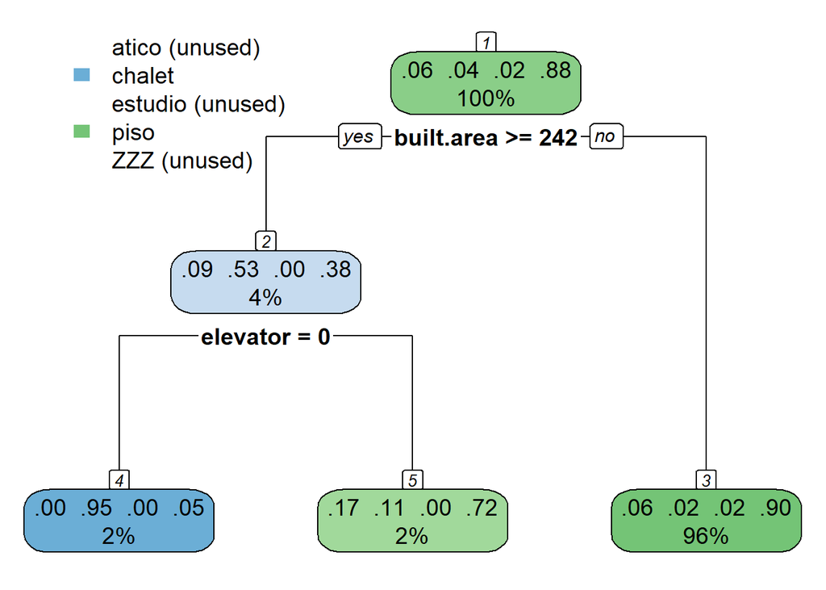

```r
rpart.plot(arbol_type,extra=105,nn=TRUE,tweak=1.2)
```

Para imputar la variable `type.house`, se utilizó un árbol de clasificación. La variable más relevante fue la superficie construida (`built.area`), observándose que las viviendas de menos de 242 m² se clasificaban mayoritariamente como pisos, mientras que en viviendas de gran tamaño la presencia o ausencia de ascensor (`elevator`) permitía distinguir principalmente entre pisos y chalets.

```r
table(datos$type.house)
```

```
  atico  chalet estudio    piso     ZZZ
    662     377     244    9229       0
```

- **FLOOR**

```r
#################################################
# 2. FLOOR
#################################################
set.seed(12345)
# Filas con valor conocido
train_floor <- datos[
  datos$floor != "ZZZ",]

# Filas con missing
test_floor <- datos[
  datos$floor == "ZZZ",]

# Árbol de clasificación
arbol_floor <- rpart(
  floor ~ built.area +
    baths +
    age +
    elevator +
    garage +
    air.cond +
    swimming.pool +
    type.house +
    good.cond +
    precio_actualizado +
    crime +
    shopping +
    historical,
  data = train_floor,
  method = "class",
  control = rpart.control(
    cp = 0.001,
    minbucket = ceiling(0.05 * nrow(train_floor)),
    minsplit = 20))

# Predicción
pred_floor <- predict(
  arbol_floor,
  test_floor,
  type = "class")

# Reemplazo
datos$floor[
  datos$floor == "ZZZ"] <- pred_floor
```

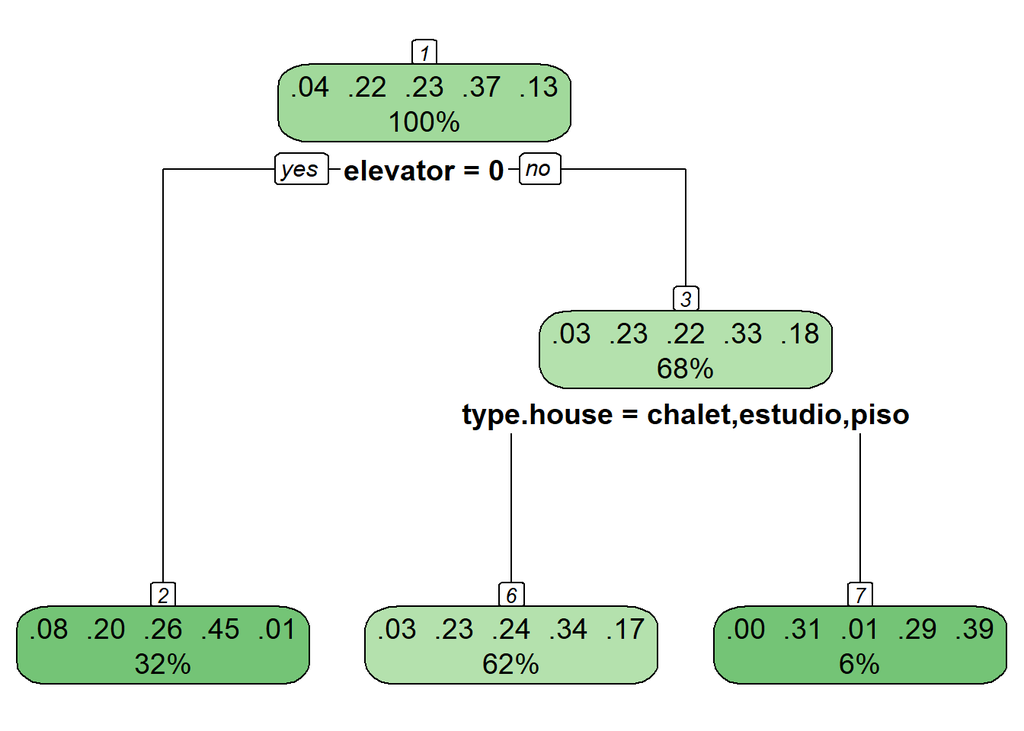

```r
library(rpart.plot)
rpart.plot(
  arbol_floor,
  extra = 105,
  nn = TRUE,
  tweak = 1.2,
  box.palette = "Greens")
```

```r
levels(train_floor$floor)
```

```
[1] "bajo"         "cuar.-quinta" "primera"      "seg.-terc."   "sexta_o_mas"
[6] "ZZZ"
```

Para imputar la variable `floor`, se ajustó un árbol de clasificación. La variable más relevante fue la presencia de ascensor (`elevator`), observándose que las viviendas sin ascensor tendían a localizarse en plantas intermedias, mientras que en viviendas con ascensor el tipo de vivienda (`type.house`) permitía diferenciar especialmente entre pisos convencionales y viviendas situadas en plantas altas como áticos.

```r
table(datos$floor)
```

```
        bajo cuar.-quinta      primera   seg.-terc.  sexta_o_mas          ZZZ
         385         1907         1980         5068         1172            0
```

> Una vez imputado todos los valores faltantes, vamos a pasar dichas variables categoricas a factor y todavia nos falta imputar `good.cond`.

```r
summary(datos)
```

```
       X          house.price          RP           crime
 Min.   :    1   Min.   :  900   Min.   :0.06   Min.   :0.0600
 1st Qu.: 2971   1st Qu.: 2828   1st Qu.:0.21   1st Qu.:0.2900
 Median : 5924   Median : 3545   Median :0.26   Median :0.4300
 Mean   : 5928   Mean   : 3728   Mean   :0.28   Mean   :0.4369
 3rd Qu.: 8896   3rd Qu.: 4400   3rd Qu.:0.33   3rd Qu.:0.5500
 Max.   :11796   Max.   :20131   Max.   :0.72   Max.   :0.7700
   built.area           age            retired         children
 Min.   :  15.00   Min.   :  0.00   Min.   :11.58   Min.   : 8.897
 1st Qu.:  62.00   1st Qu.: 15.00   1st Qu.:16.56   1st Qu.:11.181
 Median :  80.00   Median : 28.91   Median :18.68   Median :12.776
 Mean   :  98.79   Mean   : 23.93   Mean   :18.51   Mean   :12.905
 3rd Qu.: 110.00   3rd Qu.: 30.00   3rd Qu.:20.78   3rd Qu.:14.239
 Max.   :2500.00   Max.   :100.00   Max.   :22.75   Max.   :18.374
   immigrants        shopping        historical         baths
 Min.   : 6.064   Min.   :0.0000   Min.   :0.0000   Min.   :1.000
 1st Qu.: 8.043   1st Qu.:0.0000   1st Qu.:0.0000   1st Qu.:1.000
 Median :12.068   Median :0.0000   Median :0.0000   Median :1.000
 Mean   :12.624   Mean   :0.4085   Mean   :0.3456   Mean   :1.542
 3rd Qu.:17.560   3rd Qu.:1.0000   3rd Qu.:1.0000   3rd Qu.:2.000
 Max.   :20.543   Max.   :1.0000   Max.   :1.0000   Max.   :7.000
   type.house            floor           good.cond        garage
 atico  : 662   bajo        : 385   a_reformar:1569   Min.   :0.0000
 chalet : 377   cuar.-quinta:1907   bueno     :8883   1st Qu.:0.0000
 estudio: 244   primera     :1980   ZZZ       :  60   Median :0.0000
 piso   :9229   seg.-terc.  :5068                     Mean   :0.2901
 ZZZ    :   0   sexta_o_mas :1172                     3rd Qu.:1.0000
                ZZZ         :   0                     Max.   :1.0000
    elevator         air.cond      swimming.pool         M.30
 Min.   :0.0000   Min.   :0.0000   Min.   :0.0000   Min.   :0.0000
 1st Qu.:0.0000   1st Qu.:0.0000   1st Qu.:0.0000   1st Qu.:0.0000
 Median :1.0000   Median :0.0000   Median :0.0000   Median :0.0000
 Mean   :0.6553   Mean   :0.4591   Mean   :0.1763   Mean   :0.1335
 3rd Qu.:1.0000   3rd Qu.:1.0000   3rd Qu.:0.0000   3rd Qu.:0.0000
 Max.   :1.0000   Max.   :1.0000   Max.   :1.0000   Max.   :1.0000
   longitude         latitude     precio_actualizado
 Min.   :-3.792   Min.   :40.34   Min.   : 1443
 1st Qu.:-3.708   1st Qu.:40.39   1st Qu.: 4535
 Median :-3.691   Median :40.42   Median : 5685
 Mean   :-3.685   Mean   :40.42   Mean   : 5979
 3rd Qu.:-3.663   3rd Qu.:40.45   3rd Qu.: 7056
 Max.   :-3.546   Max.   :40.53   Max.   :32284
```

```r
categoricas <- c(
  "shopping",
  "historical",
  "type.house",
  "floor",
  "garage",
  "elevator",
  "air.cond",
  "swimming.pool",
  "M.30")

datos <- datos |>
  mutate(across(all_of(categoricas), as.factor))
```

Ahora eliminamos la categoria ZZZ de `type.house` y `floor`:

```r
datos$type.house <- droplevels(datos$type.house)
datos$floor <- droplevels(datos$floor)

table(datos$type.house)
```

```
  atico  chalet estudio    piso
    662     377     244    9229
```

```r
table(datos$floor)
```

```
        bajo cuar.-quinta      primera   seg.-terc.  sexta_o_mas
         385         1907         1980         5068         1172
```

Imputamos `good.cond`:

```r
datos <- datos |>
  mutate(
    good.cond = as.character(good.cond),
    good.cond = ifelse(good.cond == "ZZZ", "bueno", good.cond),
    good.cond = as.factor(good.cond)
  )

datos$good.cond <- as.factor(datos$good.cond)
datos$good.cond <- droplevels(datos$good.cond)

table(datos$good.cond)
```

```
a_reformar      bueno
      1569       8943
```

Una vez finalizado el proceso de imputación,transformamos la base de datos en un objeto espacial para poder realizar posteriormente el análisis espacial, construir mapas, calcular medidas de dependencia espacial e implementar métodos de interpolación o modelización espacial.

```r
# convertimos los datos a un objeto especial
datos_sf <- st_as_sf(datos,
                     coords = c("longitude", "latitude"),
                     crs = 4326) # WGS84
```

## 3. Limpieza espacial inicial

Dentro de la depuración espacial de la base de datos, buscamos quedarnos con los datos que tienen al menos 6 vecinos proximos. Para ello, usamos el algoritmo `DBSCAN` con el objetivo de identificar zonas con suficiente concentración de viviendas. De esta forma, se conservaron únicamente aquellas viviendas localizadas en áreas con una densidad suficiente de testigos, eliminando puntos aislados o situados en zonas con poca información disponible.

Este procedimiento permite definir una ventana espacial de trabajo más fiable. Si una nueva vivienda se encuentra dentro de alguno de los clústeres identificados, el modelo dispone de observaciones cercanas sobre las que apoyar la predicción. En cambio, si se encuentra fuera de estas agrupaciones, se considera que no existen testigos suficientes para ofrecer una valoración robusta.

```r
# Transformamos las coordenadas a metros para aplicar DBSCAN
datos_sf_metros <- st_transform(datos_sf, 25830)

# Extraemos las coordenadas proyectadas
coords_metros <- st_coordinates(datos_sf_metros)

# Aplicamos DBSCAN: mínimo 6 viviendas en un radio de 400 metros
modelo_dbscan <- dbscan(coords_metros, eps = 400, minPts = 6)

# Añadimos el identificador del clúster al objeto espacial
datos_sf_metros$cluster_dbscan <- modelo_dbscan$cluster

# Separamos las viviendas agrupadas y las observaciones aisladas
datos_limpios <- datos_sf_metros %>%
  filter(cluster_dbscan != 0)

datos_ruido <- datos_sf_metros %>%
  filter(cluster_dbscan == 0)

cat("Viviendas originales:", nrow(datos_sf_metros), "\n")
```

```
Viviendas originales: 10512
```

```r
cat("Viviendas conservadas:", nrow(datos_limpios), "\n")
```

```
Viviendas conservadas: 10307
```

```r
cat("Viviendas eliminadas como ruido:", nrow(datos_ruido), "\n")
```

```
Viviendas eliminadas como ruido: 205
```

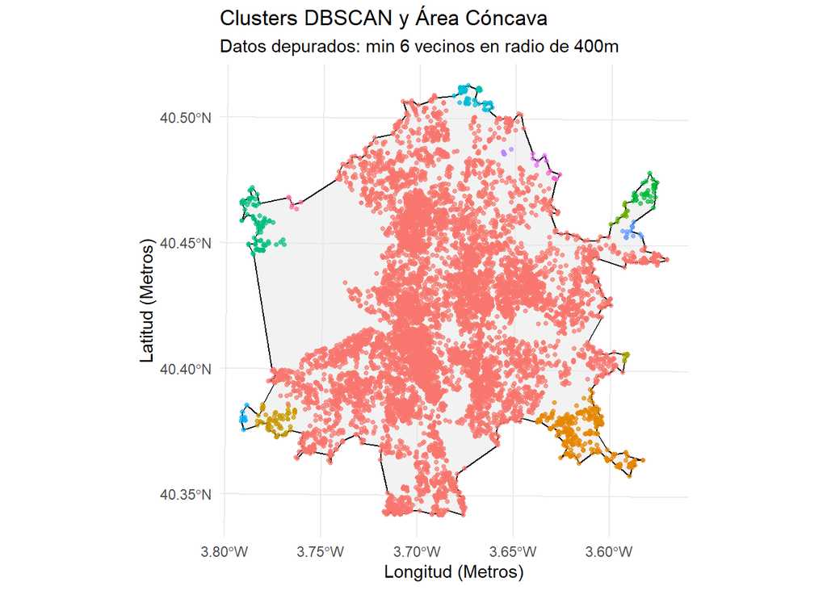

```r
# Creamos el area cóncava: generamos el polígono que envuelve los puntos ajustándose a su forma
area_concava <- concaveman(datos_limpios)

# Dibujamos los puntos agrupados por color (para ver si parecen barrios)
# Convertimos el cluster a factor (texto) para que ggplot ponga colores distintos
datos_limpios$cluster_dbscan <- as.factor(datos_limpios$cluster_dbscan)

ggplot() +
  geom_sf(data = area_concava, fill = "gray90", color = "black", size = 0.5, alpha = 0.5) +
  # Pintamos los pisos limpios, coloreados por su grupo de DBSCAN
  geom_sf(data = datos_limpios, aes(color = cluster_dbscan), size = 1, alpha = 0.7) +

  theme_minimal() +
  theme(legend.position = "none") +
  labs(
    title = "Clusters DBSCAN y Área Cóncava",
    subtitle = "Datos depurados: min 6 vecinos en radio de 400m",
    x = "Longitud (Metros)",
    y = "Latitud (Metros)")
```

> Cada cluster (cada mancha de color) le dice a tu modelo: “Aquí hay suficientes datos (testigos) como para que lo que prediga sea fiable”. Si un piso está dentro de un cluster, significa que tiene al menos 6 vecinos a menos de 400 metros. Eso da solidez estadística a tu valoración.

Hemos eliminado las observaciones especialmente aisladas mediante DBSCAN y lo mostramos con el área cóncava.

Ahora, queremos saber si tenemos datos que no tengan sentido, por ejemplo, que nos salgan viviendas en la Casa de Campo o en el Retiro. Para identificar este tipo de casos anómalos, realizamos una inspección visual sobre el mapa de Madrid.

```r
tmap_mode("view")
```

```
ℹ tmap modes "plot" - "view"
ℹ toggle with `tmap::ttm()`
```

```r
# Volvemos a WGS84 para visualizar sobre mapa web
datos_limpios_wgs84 <- st_transform(datos_limpios, 4326)
datos_ruido_wgs84  <- st_transform(datos_ruido, 4326)
# nos creamos un identificador
datos_limpios_wgs84$id_fila <- 1:nrow(datos_limpios_wgs84)
coords <- st_coordinates(datos_limpios_wgs84)
datos_limpios_wgs84$longitude <- coords[,1]
datos_limpios_wgs84$latitude  <- coords[,2]

tm_shape(datos_limpios_wgs84) +
  tm_dots(
    col = "black",
    size = 0.05,
    popup.vars = c("ID" = "id_fila",
                   "Longitud" = "longitude",
                   "Latitud" = "latitude")
  ) +
  tm_basemap("OpenStreetMap")
```

[interactive chart not shown]

Observamos que nos salen algunas viviendas de `datos_limpios` en zonas no residenciales, como por ejemplo: El Retiro, el cementerio de la Almudena, Faunia, el Cerro de San Isidro, el Parque Emperatriz María de Austria, la Quinta de los Molinos, el Parque del Oeste o el Parque Juan Carlos I.

Vamos a seleccionar el perimetro de esas zonas por coordenadas y todos las viviendas de caigan dentro las eliminaremos.

```r
# Partimos de los puntos limpios
datos_limpios_wgs84 <- st_transform(datos_limpios, 4326)

# Crear cajas de exclusión aproximadas
# 1. RETIRO: ponemos mas coordenadas porque sino nos borra viviendas que no hay que borrar
coords_retiro <- matrix(c(
  -3.6895, 40.4095,
  -3.6765, 40.4095,
  -3.6735, 40.4145,
  -3.6745, 40.4205,
  -3.6815, 40.4220,
  -3.6888, 40.4175,
  -3.6895, 40.4095
), ncol = 2, byrow = TRUE)

retiro <- st_sfc(st_polygon(list(coords_retiro)), crs = 4326)

# 2. CEMENTERIO DE LA ALMUDENA
coords_almudena <- matrix(c(
  -3.6465, 40.4210,
  -3.6330, 40.4210,
  -3.6310, 40.4255,
  -3.6325, 40.4305,
  -3.6415, 40.4310,
  -3.6470, 40.4275,
  -3.6465, 40.4210
), ncol = 2, byrow = TRUE)

almudena <- st_sfc(st_polygon(list(coords_almudena)), crs = 4326)

# 3. PARQUE EMPERATRIZ MARÍA DE AUSTRIA
coords_emperatriz <- matrix(c(
  -3.7270, 40.3825,
  -3.7160, 40.3825,
  -3.7138, 40.3875,
  -3.7155, 40.3920,
  -3.7225, 40.3922,
  -3.7275, 40.3885,
  -3.7270, 40.3825
), ncol = 2, byrow = TRUE)

emperatriz_maria_austria <- st_sfc(st_polygon(list(coords_emperatriz)), crs = 4326)

# 4. PRADOLONGO
coords_pradolongo <- matrix(c(
  -3.7145, 40.3695,
  -3.7045, 40.3695,
  -3.7020, 40.3735,
  -3.7040, 40.3775,
  -3.7105, 40.3778,
  -3.7148, 40.3745,
  -3.7145, 40.3695
), ncol = 2, byrow = TRUE)

pradolongo <- st_sfc(st_polygon(list(coords_pradolongo)), crs = 4326)

faunia <- st_as_sfc(st_bbox(c(
  xmin = -3.610, xmax = -3.594,
  ymin = 40.392, ymax = 40.402
), crs = 4326))

san_isidro <- st_as_sfc(st_bbox(c(
  xmin = -3.732, xmax = -3.719,
  ymin = 40.395, ymax = 40.404
), crs = 4326))

quinta_molinos <- st_as_sfc(st_bbox(c(
  xmin = -3.648, xmax = -3.632,
  ymin = 40.438, ymax = 40.449
), crs = 4326))

parque_oeste <- st_as_sfc(st_bbox(c(
  xmin = -3.731, xmax = -3.715,
  ymin = 40.423, ymax = 40.435
), crs = 4326))

juan_carlos <- st_as_sfc(st_bbox(c(
  xmin = -3.616, xmax = -3.594,
  ymin = 40.456, ymax = 40.470
), crs = 4326))

# Unir todas las zonas
zonas_excluir <- st_sf(
  nombre = c(
    "Retiro", "Almudena", "Faunia", "San Isidro",
    "Emperatriz Maria de Austria", "Quinta de los Molinos",
    "Parque del Oeste", "Juan Carlos I"
  ),
  geometry = st_sfc(
    retiro[[1]], almudena[[1]], faunia[[1]], san_isidro[[1]],
    emperatriz_maria_austria[[1]], quinta_molinos[[1]],
    parque_oeste[[1]], juan_carlos[[1]],
    crs = 4326
  )
)

# Detectar puntos dentro de esas zonas
inter <- st_intersects(datos_limpios_wgs84, zonas_excluir, sparse = FALSE)

datos_excluidos <- datos_limpios_wgs84[apply(inter, 1, any), ]
datos_finales   <- datos_limpios_wgs84[!apply(inter, 1, any), ]

cat("Puntos antes:", nrow(datos_limpios_wgs84), "\n")
```

```
Puntos antes: 10307
```

```r
cat("Puntos excluidos:", nrow(datos_excluidos), "\n")
```

```
Puntos excluidos: 419
```

```r
cat("Puntos finales:", nrow(datos_finales), "\n")
```

```
Puntos finales: 9888
```

En *datos_finales* tenemos todas las viviendas que no estan en zonas no residenciales, es decir, en en *datos_finales* ya tenemos todas las viviendas que estan correctamente ubicadas (muestra depurada espacialmente).

- datos: tabla original
- datos_sf: lo mismo pero en objeto espacial
- datos_sf_metros: lo mismo pero proyectado en metros para DBSCAN
- datos_limpios: muestra ya depurada espacialmente

## 4. Outliers

Ahora vamos estudiar los outliers de las variables.

> No tiene sentido estudiar los outliers en las variables binarias asique esas variables no las estudiaremos.

```r
library(patchwork)
outliers <- function(datos_finales, variable) {
  var_name <- datos_finales[[variable]]  # Acceder a la variable por nombre

  tot <- sum(!is.na(var_name))  # Total de observaciones no NA
  na1 <- sum(is.na(var_name))   # NA iniciales

  # Identificar outliers usando la regla de Tukey (coef = 1.5)
  stats_outliers <- boxplot.stats(var_name, coef = 1.5)
  outlier_values <- stats_outliers$out
  prop_outliers <- round(length(outlier_values) / tot * 100, 2)  # Proporción de outliers

  # Identificar valores extremos usando la regla de Tukey (coef = 3.0)
  stats_extremes <- boxplot.stats(var_name, coef = 3.0)
  extreme_values <- stats_extremes$out
  prop_extremes <- round(length(extreme_values) / tot * 100, 2)  # Proporción de valores extremos

  # Filtrar datos sin outliers ni valores extremos
  data_no_outliers <-
    data.frame(value = var_name) |>
    filter(!(value %in% c(outlier_values, extreme_values)))

    # Histograma con todos los datos
  p1 <- ggplot(data.frame(value = var_name), aes(x = value)) +
    geom_histogram(fill = "steelblue", color = "black", bins = 30, alpha = 0.7) +
    labs(title = "All Observations", x = variable, y = "Count") +
    theme_minimal()

  # Boxplot con outliers resaltados
  p2 <- ggplot(data.frame(value = var_name), aes(x = value)) +
    geom_boxplot(outlier.colour = "red", outlier.shape = 16, outlier.size = 3) +
    labs(title = "Boxplot with Outliers", x = variable, y = "") +
    theme_minimal()

  # Mostrar gráficos juntos con patchwork
  print(p1 / p2)

  # Mostrar información en la consola
  cat("\n📌 Outliers identified in", variable, ":", length(outlier_values), "outliers\n")
  cat("📊 Proportion (%) of outliers:", prop_outliers, "%\n")
  cat("\n🚨 Extreme values identified in", variable, ":", length(extreme_values), "extreme values\n")
  cat("📊 Proportion (%) of extreme values:", prop_extremes, "%\n")

  return(list(outliers = outlier_values, extremes = extreme_values))  # Devolver ambos valores
}
```

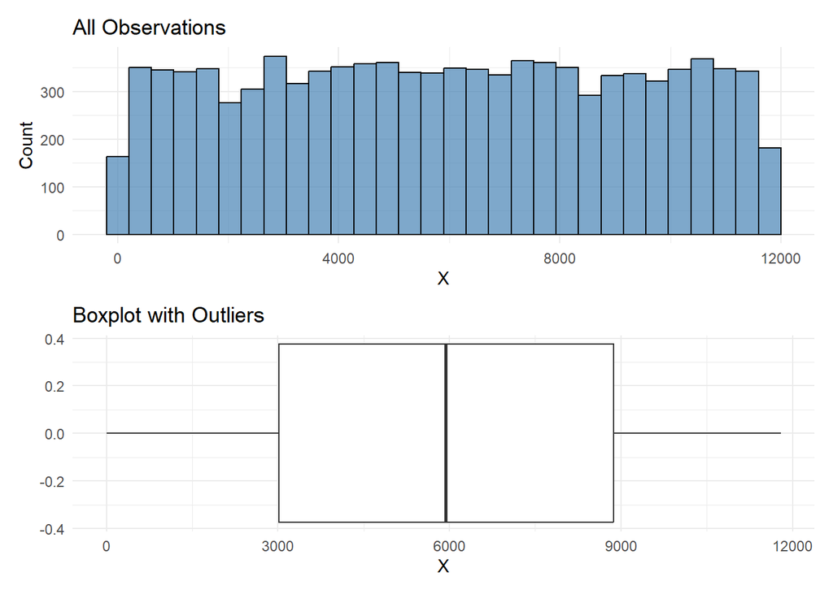

```
📌 Outliers identified in X : 0 outliers
📊 Proportion (%) of outliers: 0 %

🚨 Extreme values identified in X : 0 extreme values
📊 Proportion (%) of extreme values: 0 %
```

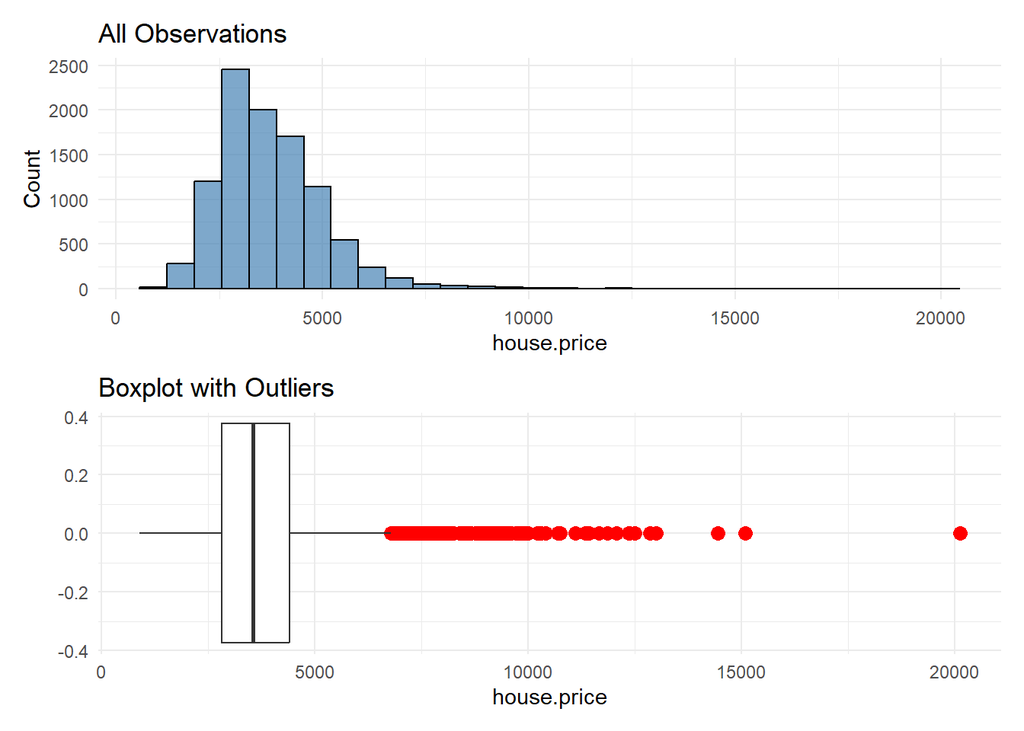

```
📌 Outliers identified in house.price : 210 outliers
📊 Proportion (%) of outliers: 2.12 %

🚨 Extreme values identified in house.price : 48 extreme values
📊 Proportion (%) of extreme values: 0.49 %
```

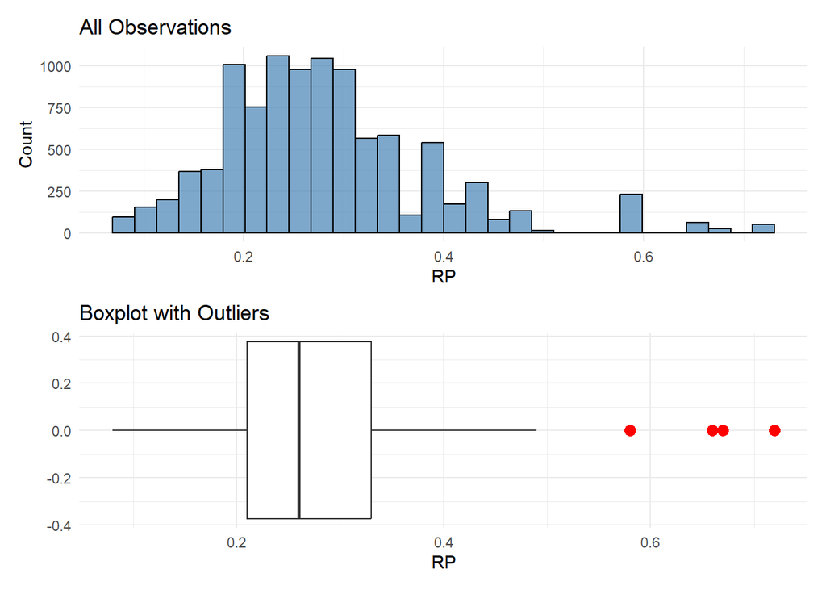

```
📌 Outliers identified in RP : 370 outliers
📊 Proportion (%) of outliers: 3.74 %

🚨 Extreme values identified in RP : 51 extreme values
📊 Proportion (%) of extreme values: 0.52 %
```

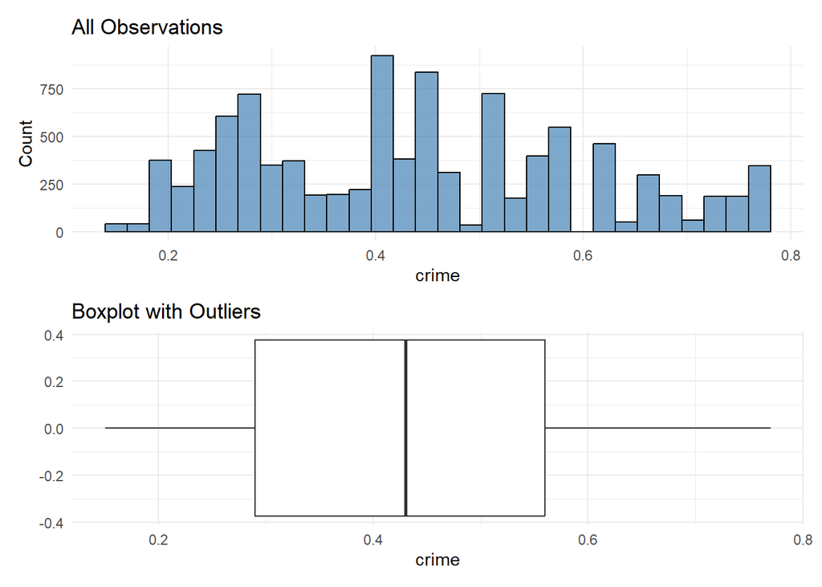

```
📌 Outliers identified in crime : 0 outliers
📊 Proportion (%) of outliers: 0 %

🚨 Extreme values identified in crime : 0 extreme values
📊 Proportion (%) of extreme values: 0 %
```

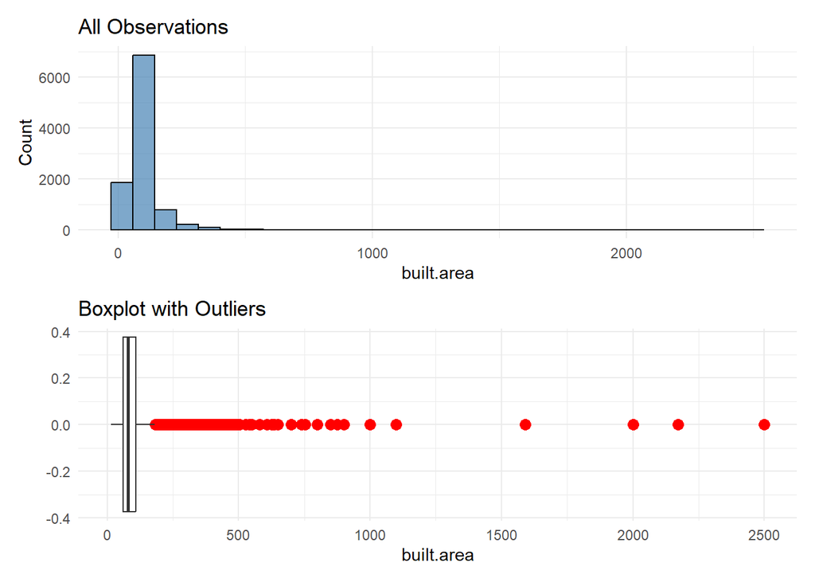

```
📌 Outliers identified in built.area : 648 outliers
📊 Proportion (%) of outliers: 6.55 %

🚨 Extreme values identified in built.area : 294 extreme values
📊 Proportion (%) of extreme values: 2.97 %
```

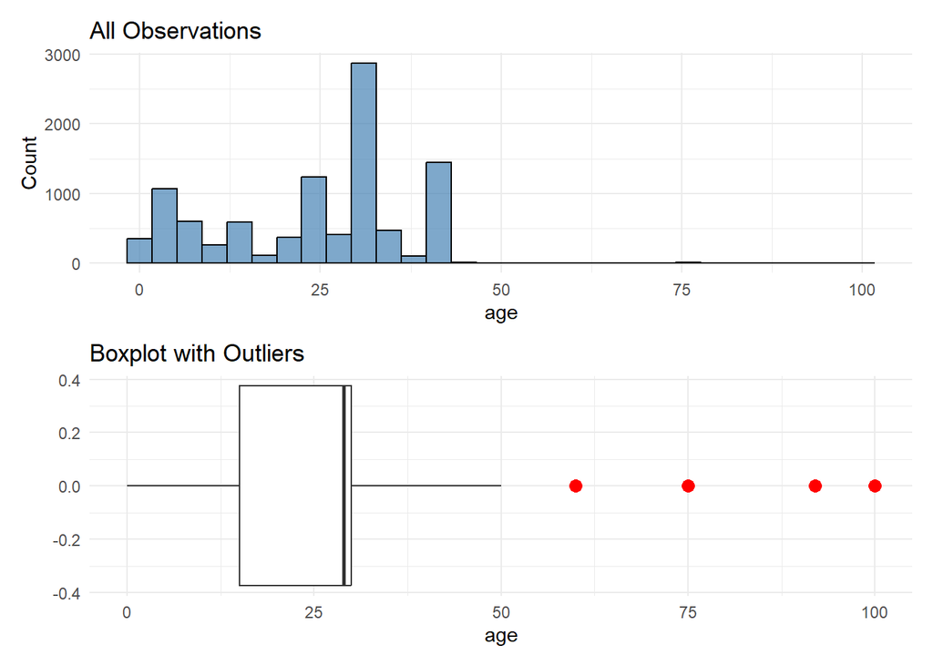

```
📌 Outliers identified in age : 11 outliers
📊 Proportion (%) of outliers: 0.11 %

🚨 Extreme values identified in age : 3 extreme values
📊 Proportion (%) of extreme values: 0.03 %
```

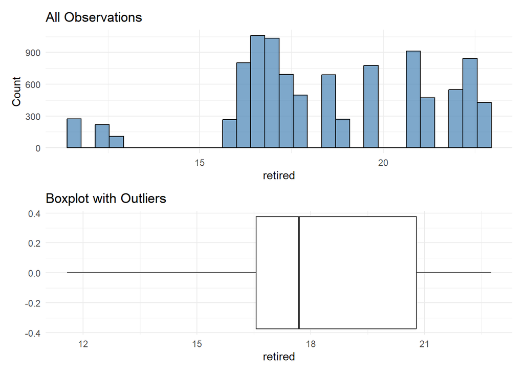

```
📌 Outliers identified in retired : 0 outliers
📊 Proportion (%) of outliers: 0 %

🚨 Extreme values identified in retired : 0 extreme values
📊 Proportion (%) of extreme values: 0 %
```

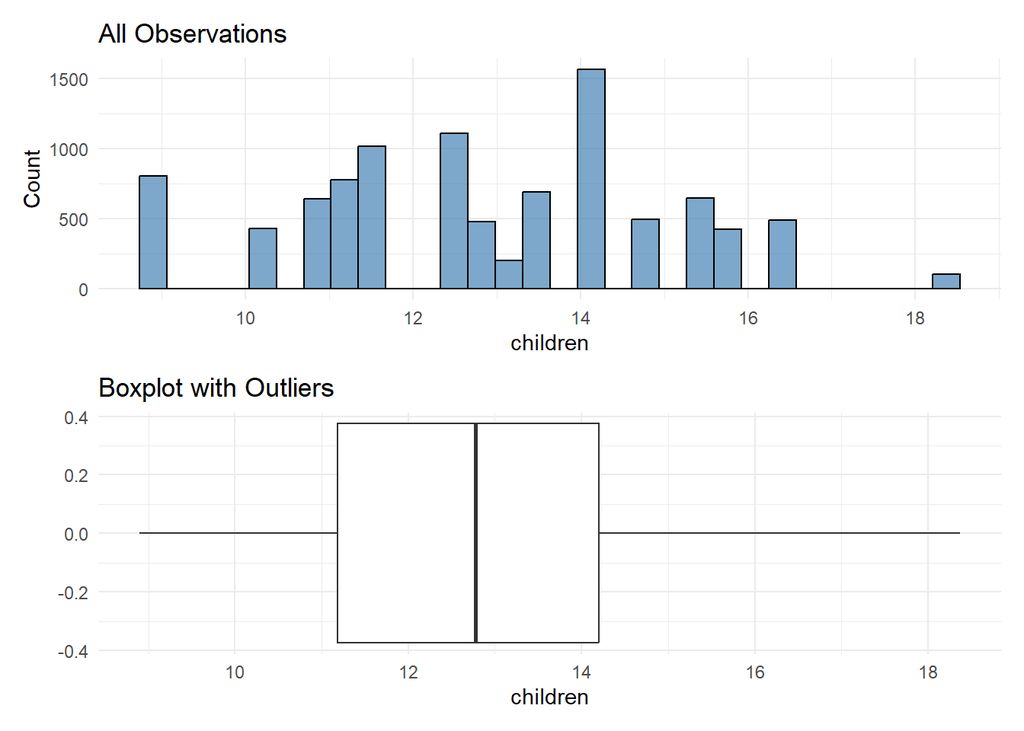

```
📌 Outliers identified in children : 0 outliers
📊 Proportion (%) of outliers: 0 %

🚨 Extreme values identified in children : 0 extreme values
📊 Proportion (%) of extreme values: 0 %
```

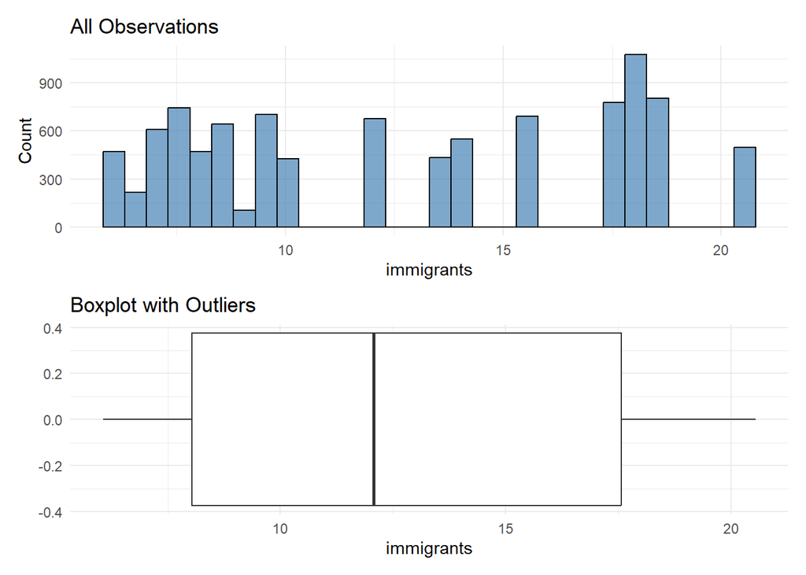

```
📌 Outliers identified in immigrants : 0 outliers
📊 Proportion (%) of outliers: 0 %

🚨 Extreme values identified in immigrants : 0 extreme values
📊 Proportion (%) of extreme values: 0 %
```

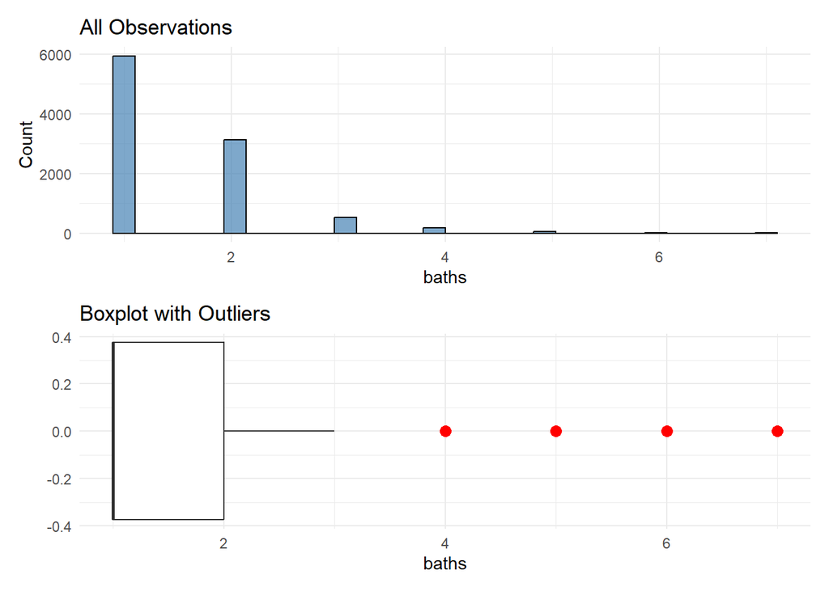

```
📌 Outliers identified in baths : 292 outliers
📊 Proportion (%) of outliers: 2.95 %

🚨 Extreme values identified in baths : 37 extreme values
📊 Proportion (%) of extreme values: 0.37 %
```

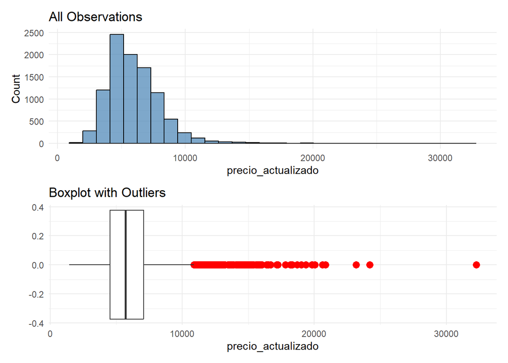

```
📌 Outliers identified in precio_actualizado : 210 outliers
📊 Proportion (%) of outliers: 2.12 %

🚨 Extreme values identified in precio_actualizado : 48 extreme values
📊 Proportion (%) of extreme values: 0.49 %
```

```r
# Aplicar la función a múltiples variables no binarias
vars_binarias <- c(
  "shopping",
  "historical",
  "garage",
  "elevator",
  "air.cond",
  "swimming.pool",
  "M.30"
)
# Nos quedamos solo con variables numéricas no binarias
vars_outliers <- names(datos_finales)[
  sapply(datos_finales, is.numeric) &
  !(names(datos_finales) %in% vars_binarias)
]

# Aplicar la función 'outliers' a cada una de las variables numéricas
outliers_results <- lapply(vars_outliers, function(var) {
outliers(datos_finales, var) # Llamar a la función pasando el nombre de la variable
})
```

El análisis de valores atípicos lo hemos hecho usando la regla de Tukey sobre las variables cuantitativas. En variables como la antigüedad o el número de baños, los valores extremos se consideraron plausibles dentro de la heterogeneidad del mercado inmobiliario, por lo que no se eliminaron automáticamente. La variable que vamos a revisar mas es la de la superficie construida, ya que presenta observaciones muy elevadas que podrian estar asociadas a errores de registro o a inmuebles muy singulares.

Observamos las observaciones que nos han salido atipicas para `built.area`:

```r
area_mas1000 <- datos_finales |>
  filter(built.area > 1000) |>
  st_drop_geometry()
area_mas1000
```

```
      X house.price   RP crime built.area      age  retired children immigrants
1  5282        5750 0.19  0.22       1100 13.50225 15.62522 15.54691   7.532427
2  3073        3086 0.17  0.25       1590 30.00000 18.79822 14.23891   8.043024
3   905        4500 0.12  0.23       2000 25.00000 18.79822 14.23891   8.043024
4  3112        5000 0.17  0.25       2500 30.00000 18.79822 14.23891   8.043024
5 11256        2302 0.19  0.40       2172 40.00000 16.94858 14.20422   7.080645
  shopping historical baths type.house      floor  good.cond garage elevator
1        1          0     6     chalet seg.-terc.      bueno      1        0
2        1          0     7     chalet seg.-terc.      bueno      1        0
3        1          0     6     chalet seg.-terc.      bueno      1        0
4        1          0     7     chalet seg.-terc.      bueno      1        0
5        0          0     6     chalet    primera a_reformar      0        0
  air.cond swimming.pool M.30 precio_actualizado cluster_dbscan
1        1             1    0           9221.142              1
2        1             1    0           4948.947              1
3        0             1    0           7216.546              7
4        1             1    0           8018.384              1
5        0             0    0           3691.664              1
```

Vemos que para las 5 observaciones con valores atipicos que nos salen, el tipo de casa es ‘Chalet’ entre 1100 y 2500 m² y con 6 o 7 baños por lo que no es disparatado y vamos a considerar que no son outliers.

## 5. Analisis exploratorio espacial

La variable objetivo es el precio por metro cuadrado:

```r
datos_finales <- datos_finales |>
  mutate(
    precio_m2 = precio_actualizado,
    log_precio_m2 = log(precio_m2))
```

Hacemos el log del precio para dejar de tener una variable muy asimetrica y tener otra más manejable donde se reduce la asimetria y hace que la variable no tenga una distribución tan sesgada, lo que es bueno para trabajar con Moran, residuos, semivariograma y kriging.

Para trabajar mejor quitamos el sf:

```r
datos_desc <- datos_finales |>
  st_drop_geometry()
```

```r
summary(datos_desc)
```

```
       X          house.price          RP             crime
 Min.   :    1   Min.   :  900   Min.   :0.0800   Min.   :0.1500
 1st Qu.: 3021   1st Qu.: 2830   1st Qu.:0.2100   1st Qu.:0.2900
 Median : 5936   Median : 3562   Median :0.2600   Median :0.4300
 Mean   : 5932   Mean   : 3732   Mean   :0.2804   Mean   :0.4398
 3rd Qu.: 8869   3rd Qu.: 4412   3rd Qu.:0.3300   3rd Qu.:0.5600
 Max.   :11796   Max.   :20131   Max.   :0.7200   Max.   :0.7700

   built.area           age            retired         children
 Min.   :  15.00   Min.   :  0.00   Min.   :11.58   Min.   : 8.897
 1st Qu.:  62.00   1st Qu.: 15.00   1st Qu.:16.56   1st Qu.:11.181
 Median :  80.00   Median : 28.96   Median :17.68   Median :12.776
 Mean   :  97.38   Mean   : 23.99   Mean   :18.51   Mean   :12.859
 3rd Qu.: 110.00   3rd Qu.: 30.00   3rd Qu.:20.78   3rd Qu.:14.204
 Max.   :2500.00   Max.   :100.00   Max.   :22.75   Max.   :18.374

   immigrants     shopping historical     baths         type.house
 Min.   : 6.064   0:5800   0:6334     Min.   :1.000   atico  : 625
 1st Qu.: 8.043   1:4088   1:3554     1st Qu.:1.000   chalet : 321
 Median :12.068                       Median :1.000   estudio: 235
 Mean   :12.721                       Mean   :1.529   piso   :8707
 3rd Qu.:17.560                       3rd Qu.:2.000
 Max.   :20.543                       Max.   :7.000

          floor           good.cond    garage   elevator air.cond swimming.pool
 bajo        : 367   a_reformar:1479   0:7065   0:3385   0:5311   0:8186
 cuar.-quinta:1798   bueno     :8409   1:2823   1:6503   1:4577   1:1702
 primera     :1861
 seg.-terc.  :4739
 sexta_o_mas :1123


 M.30     precio_actualizado cluster_dbscan   precio_m2     log_precio_m2
 0:8530   Min.   : 1443      1      :9274   Min.   : 1443   Min.   : 7.275
 1:1358   1st Qu.: 4538      2      : 295   1st Qu.: 4538   1st Qu.: 8.420
          Median : 5711      7      : 102   Median : 5711   Median : 8.650
          Mean   : 5985      3      :  64   Mean   : 5985   Mean   : 8.642
          3rd Qu.: 7075      9      :  51   3rd Qu.: 7075   3rd Qu.: 8.864
          Max.   :32284      6      :  33   Max.   :32284   Max.   :10.382
                             (Other):  69
```

```r
str(datos_desc)
```

```
'data.frame':   9888 obs. of  24 variables:
 $ X                 : int  11548 7700 6271 1620 3500 1972 4135 3925 1859 7588 ...
 $ house.price       : num  3571 3115 2940 2811 3808 ...
 $ RP                : num  0.26 0.14 0.15 0.2 0.17 0.22 0.33 0.21 0.22 0.44 ...
 $ crime             : num  0.41 0.28 0.27 0.35 0.3 0.53 0.76 0.28 0.41 0.57 ...
 $ built.area        : int  70 61 92 65 130 75 130 63 75 82 ...
 $ age               : num  40 40 40 40 15 ...
 $ retired           : num  20.8 16.9 22.2 12.4 20.8 ...
 $ children          : num  12.6 14.2 13.1 16.4 12.6 ...
 $ immigrants        : num  13.43 7.08 7.96 6.55 13.43 ...
 $ shopping          : Factor w/ 2 levels "0","1": 1 1 1 1 1 1 2 2 1 2 ...
 $ historical        : Factor w/ 2 levels "0","1": 1 1 1 1 1 1 2 2 1 2 ...
 $ baths             : int  2 1 2 1 2 1 2 1 1 1 ...
 $ type.house        : Factor w/ 4 levels "atico","chalet",..: 4 4 4 4 4 1 4 1 4 4 ...
 $ floor             : Factor w/ 5 levels "bajo","cuar.-quinta",..: 3 4 4 2 4 4 4 2 4 3 ...
 $ good.cond         : Factor w/ 2 levels "a_reformar","bueno": 2 2 1 2 2 1 2 2 2 2 ...
 $ garage            : Factor w/ 2 levels "0","1": 1 1 1 1 1 1 1 1 1 1 ...
 $ elevator          : Factor w/ 2 levels "0","1": 1 1 2 1 2 1 2 2 1 2 ...
 $ air.cond          : Factor w/ 2 levels "0","1": 1 2 1 2 1 2 1 2 1 1 ...
 $ swimming.pool     : Factor w/ 2 levels "0","1": 1 1 1 1 2 1 1 2 1 1 ...
 $ M.30              : Factor w/ 2 levels "0","1": 1 1 1 1 1 1 2 1 1 1 ...
 $ precio_actualizado: num  5727 4995 4715 4508 6107 ...
 $ cluster_dbscan    : Factor w/ 15 levels "1","2","3","4",..: 1 1 1 1 1 1 1 1 1 1 ...
 $ precio_m2         : num  5727 4995 4715 4508 6107 ...
 $ log_precio_m2     : num  8.65 8.52 8.46 8.41 8.72 ...
```

```r
nrow(datos_desc)
```

```
[1] 9888
```

> En primer lugar, se realiza un análisis exploratorio de la variable de interés mediante estadísticos descriptivos, representación cartográfica y análisis de su distribución. El objetivo es comprobar si existen patrones espaciales visibles antes de aplicar contrastes formales de autocorrelación espacial.
- **Histograma del precio actualizado y el logaritmo**

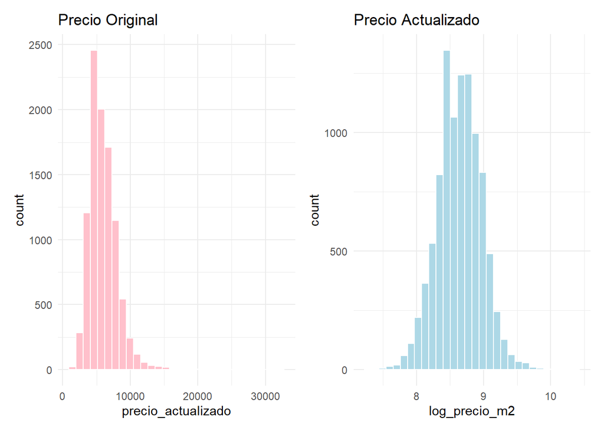

```r
p1 <- ggplot(datos_desc, aes(x = precio_actualizado)) +
  geom_histogram(fill = "pink", color = "white") +
  labs(title = "Precio Original") + theme_minimal()

p2 <- ggplot(datos_desc, aes(x = log_precio_m2)) +
  geom_histogram(fill = "lightblue", color = "white") +
  labs(title = "Precio Actualizado") + theme_minimal()

p1+p2
```

- **Tabla con estadísticos**

```r
library(skimr)
datos_desc |>
  st_drop_geometry() |>
  select(where(is.numeric)) |>
  skim()
```

Data summary

| Name | select(st_drop_geometry(d… |
| --- | --- |
| Number of rows | 9888 |
| Number of columns | 13 |
| _______________________ |  |
| Column type frequency: |  |
| numeric | 13 |
| ________________________ |  |
| Group variables | None |

**Variable type: numeric**

| skim_variable | n_missing | complete_rate | mean | sd | p0 | p25 | p50 | p75 | p100 | hist |
| --- | --- | --- | --- | --- | --- | --- | --- | --- | --- | --- |
| X | 0 | 1 | 5931.79 | 3402.76 | 1.00 | 3020.75 | 5936.50 | 8869.25 | 11796.00 | ▇▇▇▇▇ |
| house.price | 0 | 1 | 3732.36 | 1298.36 | 900.00 | 2830.00 | 3561.50 | 4412.00 | 20131.00 | ▇▂▁▁▁ |
| RP | 0 | 1 | 0.28 | 0.11 | 0.08 | 0.21 | 0.26 | 0.33 | 0.72 | ▃▇▂▁▁ |
| crime | 0 | 1 | 0.44 | 0.16 | 0.15 | 0.29 | 0.43 | 0.56 | 0.77 | ▅▅▇▃▃ |
| built.area | 0 | 1 | 97.38 | 77.05 | 15.00 | 62.00 | 80.00 | 110.00 | 2500.00 | ▇▁▁▁▁ |
| age | 0 | 1 | 23.99 | 12.34 | 0.00 | 15.00 | 28.96 | 30.00 | 100.00 | ▃▇▁▁▁ |
| retired | 0 | 1 | 18.51 | 2.75 | 11.58 | 16.56 | 17.68 | 20.78 | 22.75 | ▁▁▇▃▆ |
| children | 0 | 1 | 12.86 | 2.12 | 8.90 | 11.18 | 12.78 | 14.20 | 18.37 | ▃▇▆▅▁ |
| immigrants | 0 | 1 | 12.72 | 4.67 | 6.06 | 8.04 | 12.07 | 17.56 | 20.54 | ▇▃▅▃▆ |
| baths | 0 | 1 | 1.53 | 0.80 | 1.00 | 1.00 | 1.00 | 2.00 | 7.00 | ▇▁▁▁▁ |
| precio_actualizado | 0 | 1 | 5985.50 | 2082.15 | 1443.31 | 4538.41 | 5711.50 | 7075.42 | 32283.62 | ▇▂▁▁▁ |
| precio_m2 | 0 | 1 | 5985.50 | 2082.15 | 1443.31 | 4538.41 | 5711.50 | 7075.42 | 32283.62 | ▇▂▁▁▁ |
| log_precio_m2 | 0 | 1 | 8.64 | 0.33 | 7.27 | 8.42 | 8.65 | 8.86 | 10.38 | ▁▅▇▁▁ |

- **Matriz de correlación para observar como se comportan las variables entre ellas**

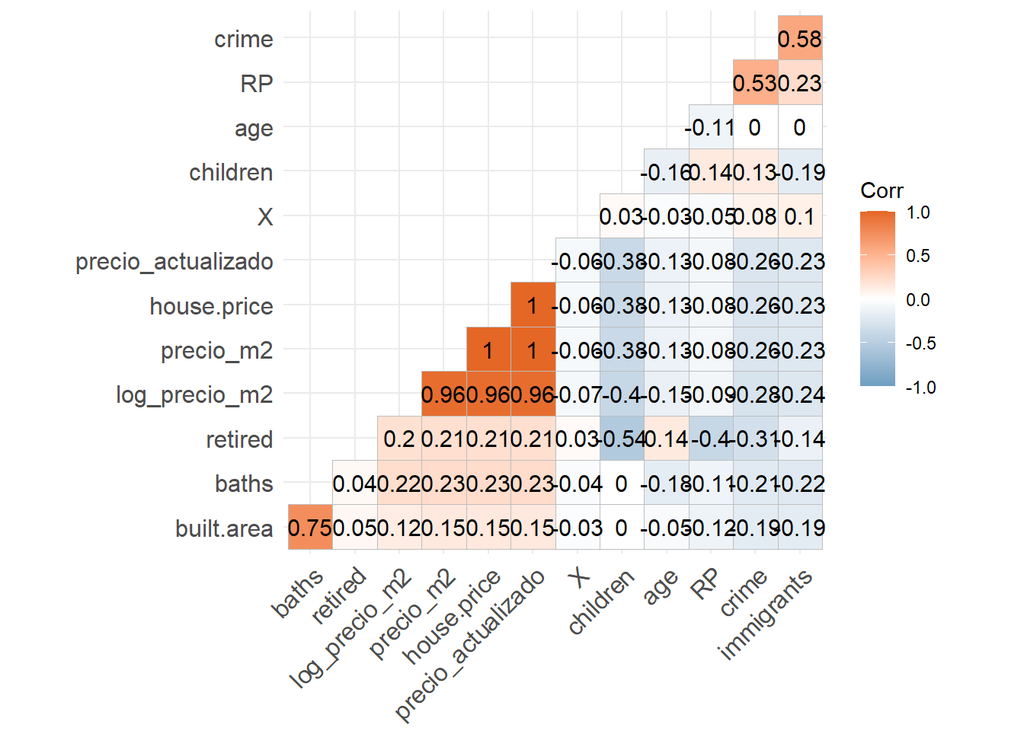

```r
library(ggcorrplot)
# Calcular matriz de correlación
corr_matrix <- datos_desc |>
  st_drop_geometry() |>
  select(where(is.numeric)) |>
  cor(use = "complete.obs") # Ignora valores faltantes

# Graficar
ggcorrplot(corr_matrix,
           hc.order = TRUE,
           type = "lower",
           lab = TRUE,
           colors = c("#6D9EC1", "white", "#E46726"))
```

```r
tmap_mode("plot")
```

```
ℹ tmap modes "plot" - "view"
```

[output not shown]

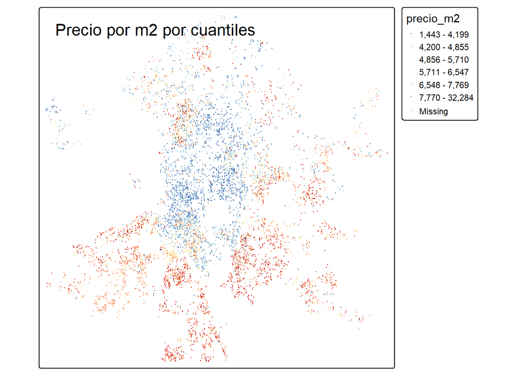

```r
tm_shape(datos_finales) +
  tm_dots(
    col = "precio_m2",
    size = 0.04,
    style = "quantile",
    n = 6,
    palette = "RdYlBu",
    title = "Precio €/m2") +
  tm_layout(
    title = "Precio por m2 por cuantiles",
    legend.outside = TRUE)
```

ESTO ES PARTE DE LA PARTE DEL ANÁLISIS DESCRIPTIVO ESPACIAL: hay que hacer todo lo que solemos hacer de ver la distribución de las variables además hay que hacer lo de los mapas coropléticos que acabamos de ver para ver las zonas y agrupar los objetos espaciales → esto al final es como hacer un análisis cluster pero con el concepto de dependencia espacial. si se sospecha con los mapas coropléticos que hay correlación espacial, y para cuantificarlo calculo la I DE MORAN Y la matriz de pesos de tipo reina para ver con este índice si realmente la hay o no y poder modelizarla. ; **del trabajo: un raster del precio de la vivienda en madrid o ventana que recoja las viviendas de madrid. El raster es para hacer una cuadrícula con el precio medio de esa zona para que cuando nos venga un dato nuevo, identifiquemos a qué cuadrícula pertenece y se lo asignemos. ; LA INTERPOLACIÓN Para cada una de las variables, nosotros usaremos los de idealista para estimar los precios en todas y con una función de la libraria sf calcularemos la cuadrícula con el precio medio de esa zona para que cuando nos venga un dato nuevo, identifiquemos a qué cuadrícula pertenece y se lo asignemos. ;

ej. trabajo: ¿cómo convierto a estacionario el precio de la vivienda? como tmbn depende de la heterogeneidad de la vivienda, estacionamos con un modelo de regresión lineal (bueno tmbn podemos hacerlo con árboles o cosas asi pero es más complejo). VA A VALORAR USAR OTRA COSA → RF. se convierte a estacionario creando un modelo que sea capaz de captar la heterogeneidad. Pvivienda= 0+1· metros2+2· altura + 3· ascensor + …. Para ver el efecto de la ubicación, hace un modelo sin la ubicación para que cuando lo añadas puedas ver su efecto. Los residuos recogen la parte de la variable que no está explicada por las explicativas. El precio medio no es estacionario porque no todas las viviendas son iguales. residuos con semivariograma plano → que los residuos no tenían dependencia, es decir, el modelo conseguía capturar toda la dependencia. Tenemos que demostrar que los residuos consiguen un semivariograma plano. la función variogram(z ~ 1, datos) por defecto así está haciendo un modelo en el que no usa ninguna como explicativa. ; la librari gstat que usamos solo permite usar modelo lineal para intentar captar esa componente de heterogeneidad. Es decir, para el trabajo si queremos en vez de una regresión lineal, un RF como no podemos usar directamente variogram(z ~ 1, datos), lo que tenemos que hacer es crear el modelo aparte, extraer los residuos y analizarlos residuos ;

Como en la base de datos de idealista tenemos muchísimas observaciones (10.000 aprox), hacemos un muestreo de testigos con 500 para train y 200 para test. ¿Hay dependencia espacial? para ver si existe esta dependencia se analiza con el semivariograma. cómo sabemos si la serie es estacionaria→ si es semi esta creciendo es porq hay una tendencia creciente en esa ubicación → si existe esta tendencia para estacional¡rizarla se crea un modelo hedónico con las características de las viviendas. de este modelo se extraen los residuos de los cuales queremos ver si son … el semivariograma plano se denomina de efecto pepita A PARTIR DE AQUÍ YA TRABAJAMOS CON LOS RESIDUOS: SI EN EL BARRIO DE SALAMANCA TODOS LOS RESIDUOS SON + ES PORQUE NO HEMOS SABIDO MODELIZAR TODA LA DEPENDENCIA. después tenemos que calcular los pesos. por el método de la distancia y el kriging obtenemos los pesos: con el método de kriging que es de optimización y minimiza la varianza del error de predicción. como se hace con gstat?? –> este trabajo quiere que lo hagamos con la base de datos que te he pasado

=0+1*m2 +…+* Wln(precio de las de alrededor) → de este modelo sacamos los residuos y vemos si tienen dependencia espacial que se hace con la I de Moran (lo del semivariograma es para mirarlo en la parte del kriging). si no hay dependencia espacial en los residuos entonces este modelo sería el definitivo. si en cambio sí existe dependencia espacial es porque hay cierta correlación que no estamos sabiendo explicar, por lo que tendremos que tratar de modelizarlo con los retardos, esto se hace añadiendo al modelo la variable retardada. en la base de datos tenemos el precio por metro cuadrado, así que vamos a modelizar/estimar esta variable y cuando la tengamos lo multiplicamos por los m2 para obtener el precio total → pero esto al final al hacer el mapa coroplético vemos si hay zonas más caras o más baratas → para ver si hay o no dependencia espacial PASOS PARA EL TRABAJO 1º hay que hacer no solo el mapa coroplético sino calcular el índice de I de Moran para ver si hay. la I toma valores entre -1 y 1, si toma valores negativos es correlación negativa, si toma valores positivos correlación positiva y si es 0 no hay correlación. La I de Moran es un indicador que nos mide H0: independencia espacial, si nos sale que hay independencia no tienen sentido hacer todo lo de la I de Moran local. el local sirve para ver si uno en particular tienen correlación espacial o no. ej: ver is una vivienda tienen asociación espacial significativa o no (es decir si depende de las de su entorno o no). las que tienen dependencia significativa las dividimos en 4 cuadrantes y las nos significativas las dejamos aparte (las ponemos un gris) de esta forma: los que tienen valor < 0.05 es significativo y por eso lo representamos con colores. los que no eran significativos los dejamos en gris → eso es lo que quiere para el trabajo

Primera visualizacion de los precios de la vivienda en Madrid. Vamos a hacer un mapa exploratorio de puntos del precio de la vivienda para ver visualmente las zonas caras y baratas.

```r
# ------------------------------------------------------------
# MAPA EXPLORATORIO DE PUNTOS
# ------------------------------------------------------------

tmap_mode("plot")
```

```
ℹ tmap modes "plot" - "view"
```

[output not shown]

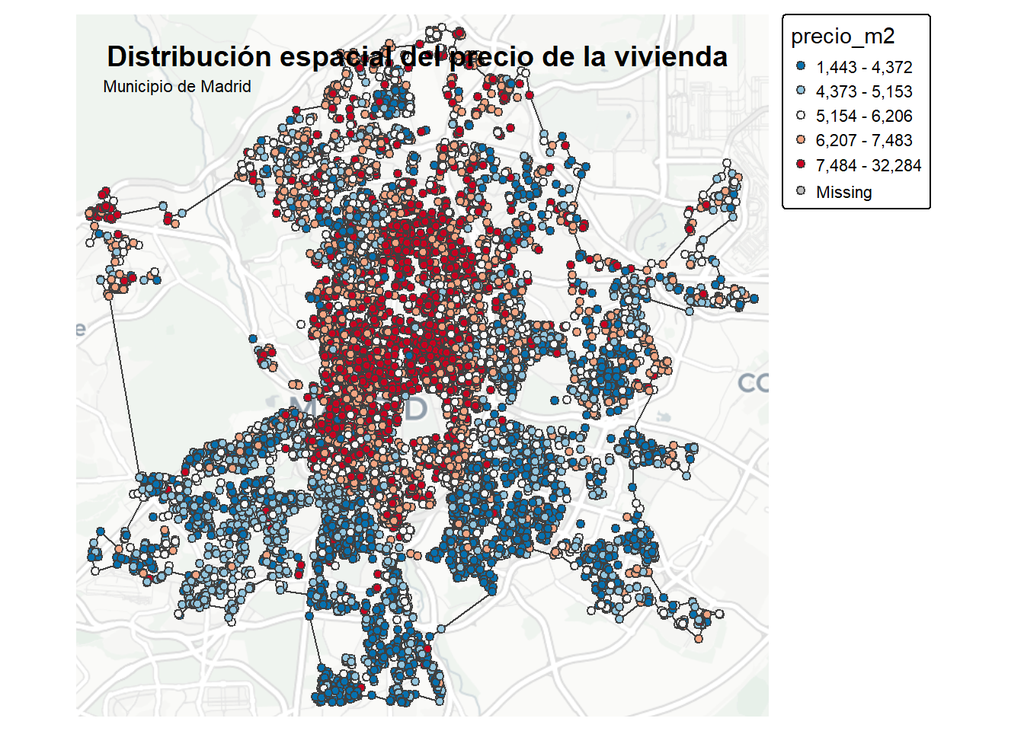

```r
# 1. Pasar puntos a metros para hacer el contorno
datos_madrid_m <- datos_finales |>
  st_transform(25830)

# 2. Crear contorno aproximado
contorno_madrid <- concaveman::concaveman(datos_madrid_m)

contorno_madrid <- st_sf(
  geometry = st_geometry(contorno_madrid),
  crs = st_crs(datos_madrid_m))

# 3. Pasar TODO a 3857 para poder usar tm_basemap()
datos_plot <- datos_madrid_m |>
  st_transform(3857)

contorno_plot <- contorno_madrid |>
  st_transform(3857)

# 4. Mapa estilo como el de tu amigo
tm_shape(contorno_plot) +
  tm_polygons(
    col = NA,
    fill_alpha = 0) +
  tm_basemap("CartoDB.Positron") +
  tm_shape(datos_plot) +
  tm_symbols(
    col = "precio_m2",      # cambia esto si tu variable se llama distinto
    style = "quantile",
    n = 5,
    palette = "-RdBu",
    size = 0.4,
    alpha = 1,
    title.col = "Precio (€/m²)") +
  tm_layout(
    title = "Distribución espacial del precio de la vivienda",
    title.size = 1.3,
    title.fontface = "bold",
    title.position = c("center", "top"),
    legend.outside = TRUE,
    legend.outside.position = "right",
    frame = FALSE) +
  tm_credits(
    "Municipio de Madrid",
    position = c("center", "top"))
```

Este mapa constituye una primera aproximación exploratoria para identificar posibles patrones de dependencia espacial en el precio de la vivienda. Se observa una concentración de precios más elevados, representados en tonos rojos, en la zona norte del municipio y en áreas como Aravaca, mientras que los precios más bajos, representados en tonos azules, se localizan principalmente en la periferia y en el sur de Madrid. Esto sugiere que el precio de la vivienda no se distribuye aleatoriamente en el espacio, sino que podría existir cierta autocorrelación espacial.

```r
library(sf)
library(openxlsx)
saveRDS(
  datos_finales,
  "datos_depurados.rds"
)
```

### I de Morgan

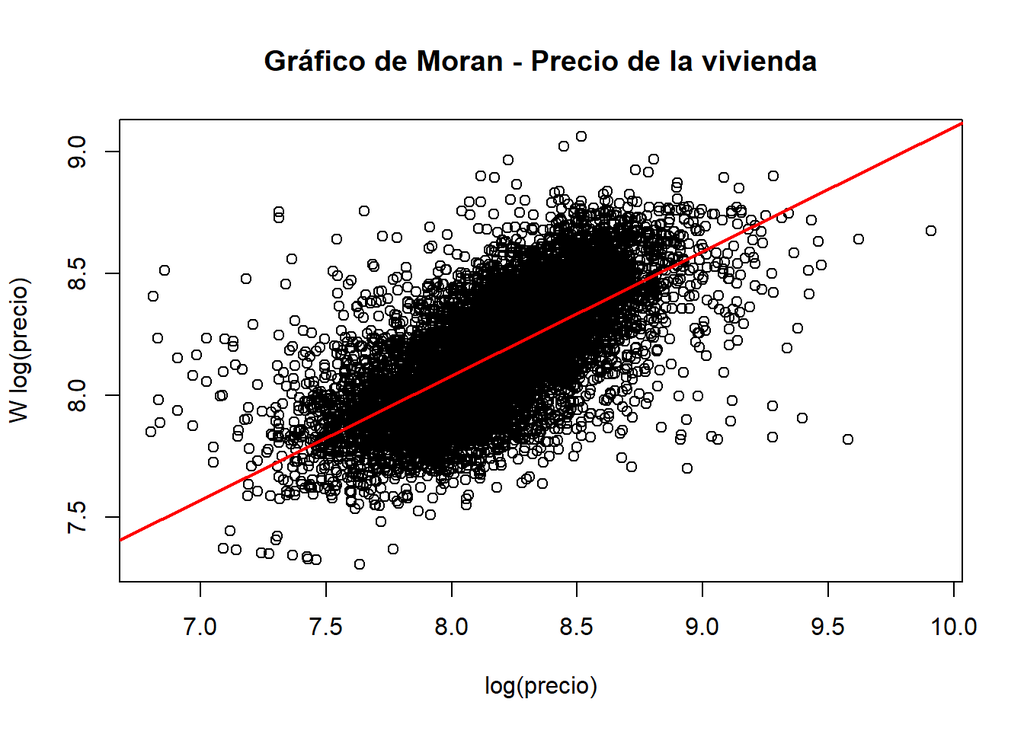

```r
# ------------------------------------------------------------
# I DE MORAN GLOBAL - PRECIO DE LA VIVIENDA EN MADRID
# ------------------------------------------------------------

# 1. Pasamos los datos a CRS métrico
# Mejor 25830 para Madrid/España: coordenadas en metros
datos_moran <- datos_finales |>
  st_transform(25830) |>
  filter(!is.na(house.price))   # cambia house.price si tu variable tiene otro nombre

# 2. Creamos la variable en logaritmos
# Si house.price es precio €/m², perfecto. Si es precio total, también se puede,
# pero para vivienda normalmente interesa precio/m2.
datos_moran <- datos_moran |>
  mutate(
    log_price = log(house.price))

# 3. Extraemos coordenadas
coords <- st_coordinates(datos_moran)

# 4. Creamos vecinos: k vecinos más cercanos
# Para puntos de vivienda es mejor que contigüidad tipo reina.
# k = 8 suele ser razonable para empezar.
knn_8 <- knearneigh(coords, k = 8)

nb_knn_8 <- knn2nb(knn_8)
# 5. Convertimos vecinos en matriz/lista de pesos espaciales
# style = "W" normaliza por filas: los pesos de cada vivienda suman 1
W_knn_8 <- nb2listw(nb_knn_8, style = "W", zero.policy = TRUE)

# 6. Precio retardado espacialmente
# Esto es el precio medio ponderado de las viviendas vecinas
datos_moran$log_price_W <- lag.listw(
  W_knn_8,
  datos_moran$log_price,
  zero.policy = TRUE)

# 7. Gráfico de Moran
plot(
  datos_moran$log_price,
  datos_moran$log_price_W,
  xlab = "log(precio)",
  ylab = "W log(precio)",
  main = "Gráfico de Moran - Precio de la vivienda")

abline(
  lm(log_price_W ~ log_price, data = datos_moran),
  col = "red",
  lwd = 2)
```

```r
# 8. I de Moran Global
I_Moran <- moran.test(
  datos_moran$log_price,
  listw = W_knn_8,
  zero.policy = TRUE,
  na.action = na.omit)

I_Moran
```

```
    Moran I test under randomisation

data:  datos_moran$log_price
weights: W_knn_8

Moran I statistic standard deviate = 107.64, p-value < 2.2e-16
alternative hypothesis: greater
sample estimates:
Moran I statistic       Expectation          Variance
     5.100746e-01     -1.011429e-04      2.246514e-05
```

El pvalor nos sale significativo. p-value < 0.05, puedes decir que hay autocorrelación espacial positiva: las viviendas caras tienden a estar cerca de viviendas caras, y las baratas cerca de viviendas baratas. Esto justificaría seguir con modelos espaciales, retardos espaciales o kriging.

Si la I de Moran es positiva y el p-valor es inferior a 0,05, se rechaza la hipótesis nula de independencia espacial. Esto indicaría que existe autocorrelación espacial positiva: las viviendas con precios altos tienden a localizarse cerca de otras viviendas caras, y las viviendas con precios bajos cerca de otras viviendas baratas.

### Mapa LISA por cuadrícula del precio de la vivienda

```r
# ------------------------------------------------------------
# MAPA LISA EN CUADRÍCULA
# ------------------------------------------------------------


# 1. Trabajamos en metros
datos_grid <- datos_finales |>
  st_transform(25830) |>
  filter(!is.na(precio_m2)) |>
  mutate(
    log_precio_m2 = log(precio_m2))

# 2. Contorno de Madrid
contorno_madrid_m <- concaveman::concaveman(datos_grid)

contorno_madrid_m <- st_sf(
  geometry = st_geometry(contorno_madrid_m),
  crs = st_crs(datos_grid))

# 3. Crear cuadrícula
# Puedes cambiar cellsize:
# 300 = celdas pequeñas
# 500 = equilibrio
# 700 = celdas más grandes y más visibles
grid_madrid <- st_make_grid(
  contorno_madrid_m,
  cellsize = 500,
  square = TRUE)

grid_madrid <- st_sf(
  id_celda = 1:length(grid_madrid),
  geometry = grid_madrid)

# 4. Recortar la cuadrícula al contorno
grid_madrid <- st_intersection(grid_madrid, st_union(contorno_madrid_m))
grid_madrid <- st_sf(
  id_celda = 1:nrow(grid_madrid),
  geometry = st_geometry(grid_madrid),
  crs = st_crs(datos_grid))

# 5. Asignar cada vivienda a una celda
puntos_en_celda <- st_join(
  datos_grid,
  grid_madrid,
  join = st_within)

# 6. Calcular precio medio por celda
precio_celda <- puntos_en_celda |>
  st_drop_geometry() |>
  filter(!is.na(id_celda)) |>
  group_by(id_celda) |>
  summarise(
    n_viviendas = n(),
    precio_m2_medio = mean(precio_m2, na.rm = TRUE),
    log_precio_m2_medio = mean(log_precio_m2, na.rm = TRUE),
    .groups = "drop")

# 7. Unir el precio medio a la cuadrícula
grid_precio <- grid_madrid |>
  left_join(precio_celda, by = "id_celda") |>
  filter(!is.na(log_precio_m2_medio))

# Opcional: quedarnos solo con celdas con suficientes viviendas
# Así evitamos celdas con 1 vivienda que pueden ser poco fiables
grid_precio <- grid_precio |>
  filter(n_viviendas >= 3)

# 8. Crear vecinos por contigüidad tipo reina
vecinos_grid <- poly2nb(
  grid_precio,
  queen = TRUE)
# Si hubiera alguna celda aislada, añadimos vecinos cercanos
coords_grid <- st_coordinates(st_centroid(grid_precio))
knn_grid <- knn2nb(
  knearneigh(coords_grid, k = 4))
vecinos_grid_final <- union.nb(vecinos_grid, knn_grid)
# 9. Matriz de pesos normalizada por filas
W_grid <- nb2listw(
  vecinos_grid_final,
  style = "W",
  zero.policy = TRUE)

# 10. Retardo espacial del precio medio
grid_precio$log_precio_m2_W <- lag.listw(
  W_grid,
  grid_precio$log_precio_m2_medio,
  zero.policy = TRUE)

# 11. I de Moran local
lmoran_grid <- localmoran(
  grid_precio$log_precio_m2_medio,
  listw = W_grid,
  zero.policy = TRUE)

grid_precio$Ii     <- lmoran_grid[, 1]
grid_precio$E.Ii   <- lmoran_grid[, 2]
grid_precio$Var.Ii <- lmoran_grid[, 3]
grid_precio$Z.Ii   <- lmoran_grid[, 4]
grid_precio$p_Ii   <- lmoran_grid[, 5]

# 12. Clasificación por cuadrantes
media_y  <- mean(grid_precio$log_precio_m2_medio, na.rm = TRUE)
media_Wy <- mean(grid_precio$log_precio_m2_W, na.rm = TRUE)

grid_precio <- grid_precio |>
  mutate(
    lisa_cluster = case_when(
      is.na(p_Ii) ~ "No significativo",
      p_Ii >= 0.05 ~ "No significativo",
      log_precio_m2_medio >= media_y & log_precio_m2_W >= media_Wy ~ "Alto-Alto",
      log_precio_m2_medio <  media_y & log_precio_m2_W <  media_Wy ~ "Bajo-Bajo",
      log_precio_m2_medio >= media_y & log_precio_m2_W <  media_Wy ~ "Alto-Bajo",
      log_precio_m2_medio <  media_y & log_precio_m2_W >= media_Wy ~ "Bajo-Alto",
      TRUE ~ "No significativo"))

# 13. Pasamos a 3857 para usar basemap
grid_lisa_plot <- grid_precio |>
  st_transform(3857)

contorno_lisa_plot <- contorno_madrid_m |>
  st_transform(3857)

# 14. Mapa LISA estilo coroplético
tmap_mode("plot")
```

```
ℹ tmap modes "plot" - "view"
```

```
[v3->v4] `tm_layout()`: use `tm_title()` instead of `tm_layout(title = )`
[plot mode] fit legend/component: Some legend items or map compoments do not
fit well, and are therefore rescaled.
ℹ Set the tmap option `component.autoscale = FALSE` to disable rescaling.
```

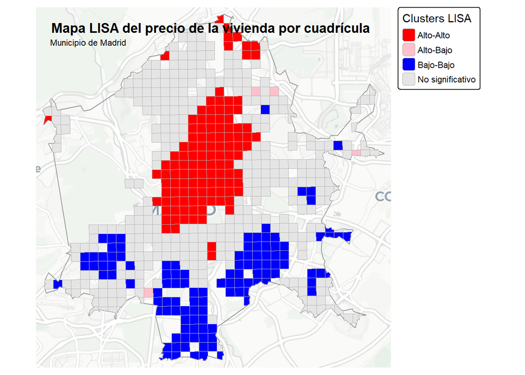

```r
tm_shape(contorno_lisa_plot) +
  tm_polygons(
    col = "grey60",
    fill_alpha = 0
  ) +
  tm_basemap("CartoDB.Positron") +
  tm_shape(grid_lisa_plot) +
  tm_polygons(
    fill = "lisa_cluster",
    col = "grey70",
    lwd = 0.2,
    fill.scale = tm_scale_categorical(
      values = c(
        "Alto-Alto" = "red",
        "Bajo-Bajo" = "blue",
        "Alto-Bajo" = "pink",
        "Bajo-Alto" = "lightblue",
        "No significativo" = "grey90"
      )
    ),
    fill.legend = tm_legend(title = "Clusters LISA")
  ) +
  tm_layout(
    title = "Mapa LISA del precio de la vivienda por cuadrícula",
    title.size = 1.2,
    title.fontface = "bold",
    title.position = c("center", "top"),
    legend.outside = TRUE,
    legend.outside.position = "right",
    frame = FALSE
  ) +
  tm_credits(
    "Municipio de Madrid",
    position = c("center", "top")
  )
```

```r
# ------------------------------------------------------------
# I DE MORAN LOCAL - MAPA LISA
# ------------------------------------------------------------

lmoran <- localmoran(
  datos_moran$log_price,
  listw = W_knn_8,
  zero.policy = TRUE
)

# Lo pasamos al objeto sf
datos_moran$Ii      <- lmoran[, 1]
datos_moran$E.Ii    <- lmoran[, 2]
datos_moran$Var.Ii  <- lmoran[, 3]
datos_moran$Z.Ii    <- lmoran[, 4]
datos_moran$p.Ii    <- lmoran[, 5]

# Variables centradas para clasificar cuadrantes
media_y  <- mean(datos_moran$log_price, na.rm = TRUE)
media_Wy <- mean(datos_moran$log_price_W, na.rm = TRUE)

datos_moran <- datos_moran |>
  mutate(
    lisa_cluster = case_when(
      p.Ii >= 0.05 ~ "No significativo",
      log_price >= media_y  & log_price_W >= media_Wy ~ "Alto-Alto",
      log_price <  media_y  & log_price_W <  media_Wy ~ "Bajo-Bajo",
      log_price >= media_y  & log_price_W <  media_Wy ~ "Alto-Bajo",
      log_price <  media_y  & log_price_W >= media_Wy ~ "Bajo-Alto",
      TRUE ~ "No significativo"
    )
  )

# Mapa LISA
tmap_mode("plot")
```

```
ℹ tmap modes "plot" - "view"
```

[output not shown]

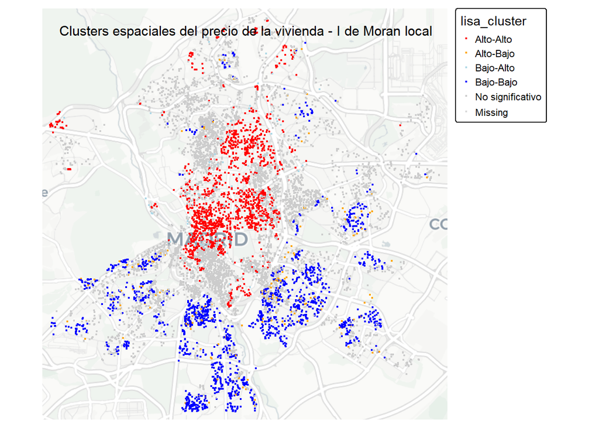

```r
datos_lisa_plot <- datos_moran |>
  st_transform(3857)

tm_shape(datos_lisa_plot) +
  tm_basemap("CartoDB.Positron") +
  tm_dots(
    col = "lisa_cluster",
    size = 0.15,
    palette = c(
      "Alto-Alto" = "red",
      "Bajo-Bajo" = "blue",
      "Alto-Bajo" = "orange",
      "Bajo-Alto" = "lightblue",
      "No significativo" = "grey80"
    ),
    title = "LISA"
  ) +
  tm_layout(
    title = "Clusters espaciales del precio de la vivienda - I de Moran local",
    legend.outside = TRUE,
    frame = FALSE
  )
```

El mapa LISA permite identificar clústeres espaciales significativos del precio de la vivienda. Las zonas Alto-Alto representan áreas donde las viviendas con precios elevados se localizan cerca de otras viviendas también caras, mientras que las zonas Bajo-Bajo indican concentración de viviendas con precios bajos. Las categorías Alto-Bajo y Bajo-Alto recogen posibles valores atípicos espaciales. Las celdas no significativas se representan en gris, ya que no muestran evidencia estadística de asociación espacial local.

La existencia de clústeres espaciales confirma que el precio de la vivienda no se distribuye aleatoriamente en el espacio, por lo que resulta necesario tener en cuenta la localización en la modelización posterior.